# Determining breeding origins of migratory birds using stable hydrogen isotopes

Clark Rushing Smithsonian Conservation Biology Institute  
Migratory Bird Center

In this lab, we will learn how to use stable hydrogen isotopes to probabilistically determine the breeding origin of migratory songbirds.

To aid this lab, I have created a very bare bones R package called *iso.assign*. This package contains several several functions used to assign birds to breeding locations and validate the performance of the model with known-origin samples. The package is located on Github so we will need to use the *devtools* package to install it. The following code will install and load the *devtools*, *iso.assign*, and *crushingr* (this package will install and load a few other necessary packages, plus set some default plotting parameters) packages:

```r
 #install.packages("devtools")
devtools::install_github("crushing05/iso.assign2")
devtools::install_github("crushing05/crushingr")

library(iso.assign2)
library(crushingr)
```

## Data

For this lab, we will be using stable hydrogen isotope data collected from breeding and non-breeding American redstarts (*Setophaga ruticilla*). These data are currently unpublished so cannot be distributed outside of this lab. To load the data, run the following lines:

```r
library(RCurl)
# Provide the web address of the file:

valURL <- getURL('https://raw.githubusercontent.com/SCBI-MigBirds/MigBirds/master/data/amre_val.csv')
stopURL <- getURL('https://raw.githubusercontent.com/SCBI-MigBirds/MigBirds/master/data/amre_stop.csv')
baseURL <- getURL('https://raw.githubusercontent.com/SCBI-MigBirds/MigBirds/master/data/amre_base.csv')

# Read in the data:

amre_val <- read.csv(text = valURL)
amre_stop <- read.csv(text = stopURL)
amre_base <- read.csv(text = baseURL)
```

The data consist of three dataframe. The first dataframe (*amre_val*) contains deuterium values (and several individual attributes) from redstarts sampled at known breeding locations. We will use these data to determine how well our assignment models can determine the breeding origin of redstarts. The second dataframe (*amre_stop*) contains deuterium values (and several individual attributes) from redstarts captured at three stopover sites along the Gulf of Mexico during spring migration. We will use these data to determine how breeding origin influences where and when individuals cross the Gulf of Mexico during spring migration.

Assigning birds to breeding origins requires a basemap of spatial variation in deuterium values (i.e., an isoscape). The third dataframe (*amre_base*) contains deuterium values for just over 6700 raster cells that make up the American redstart breeding range.

> Exercise 1: Check the first few lines of each dataframe. What are the column names in each?

```r
head(amre_val)
```

```
##   X.1 X                     site state year      band age sex     dd  lat
## 1   1 1 Balsam Mountain Preserve    NC 2010 257043984 ASY   M -62.72 35.4
## 2   2 2 Balsam Mountain Preserve    NC 2010 257043985 ASY   M -66.58 35.4
## 3   3 3 Balsam Mountain Preserve    NC 2010 257043988 ASY   M -62.24 35.4
## 4   4 4 Balsam Mountain Preserve    NC 2010 257043989 ASY   M -61.07 35.4
## 5   5 5 Balsam Mountain Preserve    NC 2010 255039826 ASY   M -59.32 35.4
## 6   6 6 Balsam Mountain Preserve    NC 2010 255039827 ASY   M -59.49 35.4
##      lon origin
## 1 -83.12   6069
## 2 -83.12   6069
## 3 -83.12   6069
## 4 -83.12   6069
## 5 -83.12   6069
## 6 -83.12   6069
```

```r
head(amre_stop)
```

```
##   X.1 X site    band.no year species       date age sex fat wing      dd
## 1   1 1  JOB 2630-01098 2012    AMRE 2012-04-17 ASY   F   2 60.0  -44.59
## 2   2 2  JOB 2630-01132 2012    AMRE 2012-04-27  SY   M   3 60.0 -150.92
## 3   3 3  JOB 2630-01133 2012    AMRE 2012-04-27 ASY   M   2 62.0  -49.41
## 4   4 4  JOB 2630-01135 2012    AMRE 2012-04-29 ASY   M   4 62.0 -156.23
## 5   5 5  JOB 2630-01136 2012    AMRE 2012-04-29 ASY   M   4 62.5  -90.13
## 6   6 6  JOB 2630-01143 2012    AMRE 2012-05-02 ASY   M   2 62.0  -95.41
##   day
## 1  22
## 2  32
## 3  32
## 4  34
## 5  34
## 6  37
```

```r
head(amre_base)
```

```
##     long   lat     dd rel.abun
## 1 -120.8 62.17 -159.2  0.11245
## 2 -120.5 62.17 -161.0  0.10475
## 3 -118.5 62.17 -159.6  0.05367
## 4 -118.2 62.17 -158.4  0.05367
## 5 -117.8 62.17 -157.2  0.02369
## 6 -117.5 62.17 -157.1  0.02066
```

*Site note for those of you that are interested. The deuterium isoscape was created by first downloading a raster file containing predicted precipitation deuterium values for North America (link). This map was then clipped to contain only cells within the redstart breeding range (this was done in ArcGIS but could easily be done in R). Finally, the precipitation deuterium values were converted to feather deuterium using the published (Hobson et al. 2012 PlosOne) correction:*

> Exercise 2: What type of object is the basemap?

Before moving on, let’s quickly visualize both the $\delta ^2H_f$ isoscape and redstart breeding abundance. To do this in ggplot2, we’ll use geom_raster():

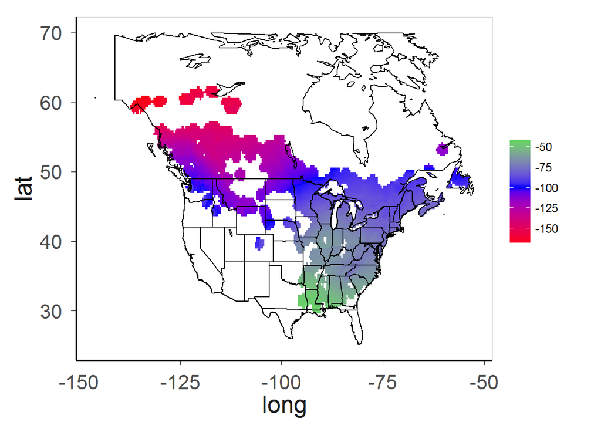

```r
# Get polygon boundaries for states and countries
  all_countries <- map_data("world") %>%
         filter(region %in% c("Canada", "USA") & long < -30 & lat > 30 & lat < 70)
  all_countries <- all_countries[-which(all_countries$subregion =="Alaska"),]
  all_states <- map_data("state")

# Plot d2H isoscape
  ggplot() +
    geom_raster(data = amre_base, aes(x = long, y = lat, fill = dd)) +
    geom_polygon(data=all_states, aes(x=long, y=lat, group = group),colour="black", fill =NA) +
    geom_polygon(data=all_countries, aes(x=long, y=lat, group = group),colour="black", fill =NA) +
    scale_fill_gradient2(low = "red", mid = "blue", high = "green", midpoint = -100)
```

> Exercise 3:  
> 1. Change the isoscape we just created to show breeding abundance instead of $\delta ^2H_f$ values.  
> 2. Change the fill gradient to go from off white (use #fbf4eb) to red.

## Basic assignment functions

The primary function for this lab will be iso_assign(). As with all R functions, we can (and should!) see what iso_assign() does behind the scenes.

> Exercise 4: View the code that the iso_assign() function uses.

```r
iso_assign
```

```
## function (dd, df.base, odds = 3)
## {
##     assign <- data.frame(matrix(ncol = length(dd), nrow = length(df.base)))
##     colnames(assign) <- seq(1:length(dd))
##     tassign <- t(assign)
##     colnames(tassign) <- round(df.base, digits = 2)
##     assign <- t(tassign)
##     for (i in 1:length(dd)) {
##         for (k in 1:length(df.base)) {
##             assign[k, i] = dnorm(dd[i], mean = df.base[k], sd = 12)
##         }
##     }
##     iso.prob <- apply(assign, 2, function(x) x/max(x))
##     iso.origin <- ifelse(iso.prob < 1/odds, 0, 1)
##     iso.data <- list(iso.like = data.frame(assign), iso.prob = data.frame(iso.prob),
##         iso.origin = data.frame(iso.origin))
##     return(iso.data)
## }
## <environment: namespace:iso.assign2>
```

Let’s start with the arguments (most of this information can also be obtained by typing ?iso_assign). iso_assign() takes three arguments, two of which are required:

1. *dd* A vector containing the $\delta ^2H_f$ values of the individuals we want to assign. There is no limit to number of individuals we can assign but it is usually best to apply the function to groups of individuals that share some common attribute (e.g., sampling site, age, sex, etc.).
2. *df.base* A vector containing the predicted $\delta ^2H_f$ values for each breeding cell. Note that this is a vector, not a dataframe, which means that this function does not contain any information about where each breeding cell is located. That’s ok because later on we will merge the assignment output with the lat/long information for the original basemap file.
3. *odds* The odds ratio used to classify breeding cells as likely or likely. Odds takes an integer value and sets the likely threshold as 1/odds. So if odds = 3 (the default value), all cells with a relative probabilty < 0.33 will be classified as unlikely (and all cells with relative probability > 0.33 will be classified as likely).

Now let’s look at the first few lines of the function:

```r
    assign <- data.frame(matrix(ncol = length(dd), nrow = length(df.base)))
    colnames(assign) <- seq(1:length(dd))
    tassign <- t(assign)
    colnames(tassign) <- round(df.base, digits = 2)
    assign <- t(tassign)
```

These lines are simply setting up an empty dataframe, called **assign**. Each row represents one breeding cell (`nrow = length(df.base)`) and each column represents one individual in our sample (`ncol = length(dd)`). We have found that, for some reason unknown to us, including row names speeds up the assignment model. So the next few lines set the column names of the original df, tranpose the df, sets the column names of the transposed df, and the transposes back to the original format.

The next few lines actually do the likelihood estimation:

```r
    for (i in 1:length(dd)) {
        for (k in 1:length(df.base)) {
            assign[k, i] = dnorm(dd[i], mean = df.base[k], sd = 12)
        }
    }
```

For each individual (indexed by *i*), the function loops over each breeding cell (indexed by *k*) and estimates the likelihood that the individual originated from that cell. It does this using the *dnorm* function, which calculates the probability that a given value (in this case, the individual’s $\delta ^2H_f$ value) came from a normal distribution with a given mean (in this case, the predicted $\delta ^2H_f$ value for that cell) and a given standard deviation (which in this case, we assume to be 12). The likelihood for each cell is stored in the **assign** dataframe we created above. After estimating the likelihood for each cell, the function then goes on to the next individual and does it all over again. Pretty simple.

The next two lines calculate the relative probabilities for each cell and the likely/unlikely cells:

```r
    iso.prob <- apply(assign, 2, function(x) x/max(x))
    iso.origin <- ifelse(iso.prob < 1/odds, 0, 1)
```

For each individual, the relative probabilities are estimated by dividing each cells’ likelihood value by the highest likelihood value of all the cells. The apply function makes this easy. We simply tell it to take the **assign** dataframe and apply a function to each column (i.e, individual) separately (that’s what the 2 does. A 1 would apply the function to rows). In this case, the function takes each value (x) and divides it by the maximum value of x within that column. So now all cells have a relative likelihood between 0 and 1, stored in an object called **iso.prob**. The next line takes the relative probabilities and converts them in 0’s or 1’s based on whether the relative probabilities are > or < the odds ratio we specified.

> UnderRstanding quesiton 1: What are the dimensions of the *iso.prob* and *iso.origin* objects?

The last two lines package the raw likelihoods, relative probabilities, and likely/unlikely cells into a list, which is returned by the function.

```r
    iso.data <- list(iso.like = assign, iso.prob = iso.prob,
        iso.origin = iso.origin)
    return(iso.data)
```

> UnderRstanding quesiton 2: What are the dimensions of the *iso.data* object?

## Assignment validation using known-origin samples

Assignment models are only useful if they can correctly identify the origin of (most) individuals so an important first step to this analysis is determine how well our assignment models perform. We will do this by applying the iso_assign() function to American redstarts that were sampled at their breeding site. Because their origin is known[^1], we can use some simple summary statistics to quantify the performance of our model.

Our validation data contains 110 individuals from 6 breeding sites. We will first apply the iso_assign() function to all individuals within each site.

```r
# Subset birds from each site
  nc <- amre_val %>% filter(state == " NC")
  la <- amre_val %>% filter(state == " LA")
  vt <- amre_val %>% filter(state == " VT")
  md <- amre_val %>% filter(state == " MD")
  mi <- amre_val %>% filter(state == " MI")
  mo <- amre_val %>% filter(state == " MO")

# Assign individuals
  nc.assign <- iso_assign(dd = nc$dd, df.base = amre_base$dd)
  la.assign <- iso_assign(dd = la$dd, df.base = amre_base$dd)
  vt.assign <- iso_assign(dd = vt$dd, df.base = amre_base$dd)
  md.assign <- iso_assign(dd = md$dd, df.base = amre_base$dd)
  mi.assign <- iso_assign(dd = mi$dd, df.base = amre_base$dd)
  mo.assign <- iso_assign(dd = mo$dd, df.base = amre_base$dd)

# Recombine assignments
  amre.like   <- cbind(nc.assign$iso.like, la.assign$iso.like, vt.assign$iso.like,
                       md.assign$iso.like, mi.assign$iso.like, mo.assign$iso.like)
  amre.prob   <- cbind(nc.assign$iso.prob, la.assign$iso.prob, vt.assign$iso.prob,
                       md.assign$iso.prob, mi.assign$iso.prob, mo.assign$iso.prob)
  amre.origin <- cbind(nc.assign$iso.origin, la.assign$iso.origin, vt.assign$iso.origin,
                       md.assign$iso.origin, mi.assign$iso.origin, mo.assign$iso.origin)
```

Ok, now all of the individuals have be assigned to potential breeding locations. There are many ways to validate our model but we will use two relatively simple metrics of accuracy and precision.

The first step in our model validation is to determine whether or not each individual was correctly assigned to it’s actual breeding location. We will call this accuracy and it is pretty straightforward to estimate. In our original dataframe, one of the columns is called **origin** and contains the cell (actually the row) of the basemap that corresponds to the individuals’ breeding location. So all we need to do is determine, for each individual, whether that origin cell was correctly classified as likely. To make it even easier, the *iso.assign* package comes with a function to estimate the error rate (i.e., the proportion of individuals that are incorrectly assigned. Error rate is just 1 - accuracy but I find it more intuitive to think about minimizing error). First, let’s look at the function:

```r
  error_rate
```

```
## function (origin, origin.cell)
## {
##     correct <- integer()
##     for (i in 1:length(origin.cell)) {
##         correct[i] <- origin[origin.cell[i], i] == 1
##     }
##     err_rate <- 1 - mean(correct)
##     return(err_rate)
## }
## <environment: namespace:iso.assign2>
```

Under the hood, this is a very simple function. It first creates an empty vector called **correct**. Next, it loops over each individual (i.e., column) and checks whether that individuals’ true origin is classified as likely. Finally, it estimates the proportion of individuals that were misclassified and returns that value.

Now let’s apply the error rate function, first to all of the redstarts in our sample (to get the overall error rate) and then to each site separetely to see if there is any geographic variation in the model accuracy.

```r
## Overall error rate
# Because the columns (i.e. individuals) of our assignment output may be different from the original
#  order of individuals, we need to recombine the origin cells to be sure they are consistent
  amre.new.origin <- c(nc$origin, la$origin, vt$origin, md$origin, mi$origin, mo$origin)
  error_rate(origin = amre.origin, origin.cell = amre.new.origin)
```

```
## [1] 0.06364
```

```r
## Error rate by site
# North Carolina
  error_rate(origin = nc.assign$iso.origin, origin.cell = nc$origin)
```

```
## [1] 0.07143
```

```r
# Louisiana
  error_rate(origin = la.assign$iso.origin, origin.cell = la$origin)
```

```
## [1] 0.05
```

```r
# Vermont
  error_rate(origin = vt.assign$iso.origin, origin.cell = vt$origin)
```

```
## [1] 0.0625
```

```r
# Maryland
  error_rate(origin = md.assign$iso.origin, origin.cell = md$origin)
```

```
## [1] 0.05
```

```r
# Michigan
  error_rate(origin = mi.assign$iso.origin, origin.cell = mi$origin)
```

```
## [1] 0
```

```r
# Missouri
  error_rate(origin = mo.assign$iso.origin, origin.cell = mo$origin)
```

```
## [1] 0.15
```

That’s good news, 6% is about as low as we could hope for. But accuracy is not the only metric of success. We could easily get 0% error rate by just calling the entire breeding range “likely” but that wouldn’t do us any good! What we really want it to get the assignment right but also identify the smallest area possible as “likely.” That assignment area, which we will call precision, is also easy to measure: it’s just the number of “likely” cells. As with the error rate, the *iso.assign* package has a built in function to estimate assignment area:

```r
  area_assign
```

```
## function (origin)
## {
##     cells <- apply(origin, 2, sum)
##     area <- mean(cells)/nrow(origin)
##     return(area)
## }
## <environment: namespace:iso.assign2>
```

This function is even more simple than error_rate(). The function first uses the apply function to estimate the number of likely cells for each individual.

> UnderRstanding quesiton 3: What function is used by apply() to determine the number of likely cells?

Next, the function estimates the mean number of cells per individual and divides it by the total number of breeding cells. This proportion, which we interpret at the average proportion of the breeding range identified as likely for each individual, is then returned.

This function is so simple it may seem silly to even have a function at all.

> UnderRstanding quesiton 4: What are some of the advantages of putting even simple code in functions?

Apply the area_assign() function to the redstart assignment:

```r
# Overall assignment area
  area_assign(origin = amre.origin)
```

```
## [1] 0.3489
```

```r
# Assignment area for each site
  area_assign(origin = nc.assign$iso.origin)
```

```
## [1] 0.3156
```

```r
  area_assign(origin = la.assign$iso.origin)
```

```
## [1] 0.2109
```

```r
  area_assign(origin = vt.assign$iso.origin)
```

```
## [1] 0.4066
```

```r
  area_assign(origin = md.assign$iso.origin)
```

```
## [1] 0.3792
```

```r
  area_assign(origin = mi.assign$iso.origin)
```

```
## [1] 0.4359
```

```r
  area_assign(origin = mo.assign$iso.origin)
```

```
## [1] 0.3465
```

So on average, about 34.89% of the breeding range is classified as likely for each individual, although some sites are quite a bit lower (e.g. Lousiana at 21.09%) and some were quite a bit higher (e.g. Michigan at 43.59%). This is pretty typical of assignments based only on hydrogen data - the resolution of one isotope is pretty low so fairly large areas get identified as likely. But at least we know the model is getting the origin right nearly 95% of the time!

[^1] This is not technically true. We sample a bird at a given location but the feather we collect for isotope analysis was actually grown the previous year. If the bird is breeding at the same location as the previous year (i.e. showed site fidelity), than we are good. However, if the bird dispersed between different breeding sites, than our sample does not actually represent the current breeding location. For this reason, we typically use only adult birds for our validation (because adults tend to show higher site fidelty than young individuals) and we eliminate individuals with $\delta ^2H_f$ values that are really different from other individuals sampled at the same location. Furthermore, because most birds disperse relatively short distances (< a few km) and our isotope data is relatively corse (> 10’s km), most dispersal events won’t greatly influence our conclusions. For these reasons, we can be fairly confident that our validation samples provide an accurate estimate of model performance.

## Assignment of stopover samples

Now that we are confident that the assignment model works, we will move on to answering some interesting biological questions about migration behavior. For this analysis, we will use $\delta ^2H_f$ values collected from American redstarts stopping over on the gulf coast during their spring migration. Individuals were captured at three sites spanning the Gulf of Mexico: Mad Island, TX, Johsnon’s Bayou, LA, and Apalachicola, FL.

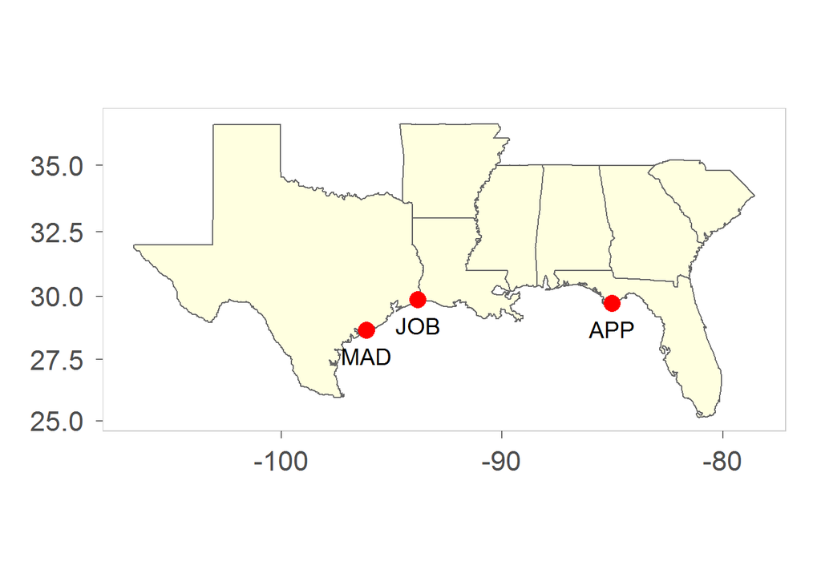

```r
  site.coords <- data.frame(site = c("MAD", "JOB", "APP"),
                          lat = c(28.65, 29.85, 29.72),
                          long = c(-96.11, -93.78, -84.99))

  gulf_states <- map_data("state") %>% filter(region %in% c("texas", "louisiana", "mississippi",
                                                          "georgia","alabama", "florida", "arkansas",
                                                          "south carolina"))

  ggplot() + coord_map() +
  geom_polygon(data = gulf_states, aes(x = long, y = lat, group = region),
                 fill = "lightyellow", color = "grey40") +
  geom_point(data = site.coords, aes(x = long, y = lat, label = site), color = "red", size = 5) +
  geom_text(data = site.coords, aes(x = long, y = lat, label = site), vjust = 2) +
  theme(axis.line = element_blank(), axis.title = element_blank())
```

In addition to the $\delta ^2H_f$ values, the *amre_stop* dataset also contains covariates for each individual:

```r
  head(amre_stop)
```

```
##   X.1 X site    band.no year species       date age sex fat wing      dd
## 1   1 1  JOB 2630-01098 2012    AMRE 2012-04-17 ASY   F   2 60.0  -44.59
## 2   2 2  JOB 2630-01132 2012    AMRE 2012-04-27  SY   M   3 60.0 -150.92
## 3   3 3  JOB 2630-01133 2012    AMRE 2012-04-27 ASY   M   2 62.0  -49.41
## 4   4 4  JOB 2630-01135 2012    AMRE 2012-04-29 ASY   M   4 62.0 -156.23
## 5   5 5  JOB 2630-01136 2012    AMRE 2012-04-29 ASY   M   4 62.5  -90.13
## 6   6 6  JOB 2630-01143 2012    AMRE 2012-05-02 ASY   M   2 62.0  -95.41
##   day
## 1  22
## 2  32
## 3  32
## 4  34
## 5  34
## 6  37
```

These attributes will allow us to ask many other interesting questions, including when birds cross the Gulf in relation to where they breed, how this passage timing differs across age/sex classes, how breeding location influences body condition at crossing, and potentially many others.

Before we can answer any of these questions, we have to do the assignments!

```r
  ## Subset data by site
  app_stop <- amre_stop %>% filter(site == "APP")
  job_stop <- amre_stop %>% filter(site == "JOB")
  mad_stop <- amre_stop %>% filter(site == "MAD")

## Assign individuals from each site
  app_assign <- iso_assign(dd = app_stop$dd, df.base = amre_base$dd)
  job_assign <- iso_assign(dd = job_stop$dd, df.base = amre_base$dd)
  mad_assign <- iso_assign(dd = mad_stop$dd, df.base = amre_base$dd)
```

One of the first things we can do with these assignments is visualize where individuals from each site are breeding. We only want one map per site so we need to first summarise all of the individuals assignments within each site.

> Exercise 4:  
> 1. For each site, use the apply function to sum the number of individuals assigned (i.e. origin == likely) to each breeding cell.  
> 2. Divide the the summed likely values for each cell by the total number of individuals from the site to get the relative probability of origin for each cell.

```r
  ## Create dataframe with assignment results
  amre_assign <- data.frame(Latitude = amre_base$lat,
                            Longitude = amre_base$long,
                            app_origin = apply(app_assign$iso.origin, 1,sum)/ncol(app_assign$iso.like),
                            job_origin = apply(job_assign$iso.origin, 1,sum)/ncol(job_assign$iso.like),
                            mad_origin = apply(mad_assign$iso.origin, 1,sum)/ncol(mad_assign$iso.like))
```

One problem with this dataframe is that it’s not *tidy*.

> UndeRstanding questions 4 & 5: What makes it untidy? Why is that a problem?

> Exercise 5: Tidy the amre_assign dataframe.

```r
  amre_tidy <- amre_assign %>%
                 gather(site, origin.prob, -Latitude, -Longitude) %>%
                   separate(site, into = c("site", "origin"), sep = "\\_") %>%
                     select(-origin)
```

Now that we have a tidy dataframe, plotting the assignment results is simple:

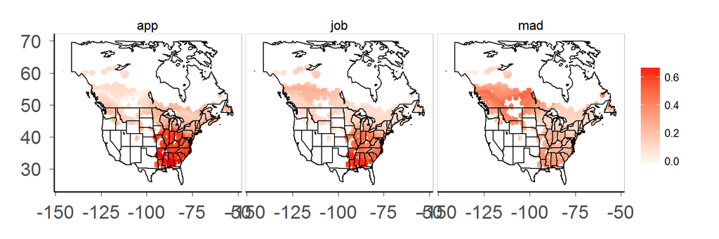

```r
  amre_map <- ggplot() +
        geom_raster(data = amre_tidy, aes(x = Longitude, y = Latitude, fill = origin.prob)) +
        geom_polygon(data=all_states, aes(x=long, y=lat, group = group),colour="black", fill =NA) +
        geom_polygon(data=all_countries, aes(x=long, y=lat, group = group),colour="black", fill =NA) +
        scale_fill_gradient(low = "#fbf4eb", high = "red") +
        facet_wrap(~site, nrow = 1) +
        theme(axis.title = element_blank())
  amre_map
```

This map shows that there are clear differences in the breeding origin of individuals stopping over at the three sites. As you might predict, the birds stopping over at Apalachicola mainly breed in the southeastern portion of the breeding range whereas birds crossing at Mad Island are mainly going to the northwest. Johnson’s Bayou appears to be somewhat intermediate, though the difference between MAD and JOB is pretty striking given how close the two sites are.

The spatial variation in Gulf passage is very interesting but there may also be temporal variation as well. Most studies of stopover ecology have suggested that birds breeding at southern latitudes pass through stopoever sites earlier than birds heading to more northerly breeding sites. We can use our dataset to test this prediction for American redstarts at three separate stopover sites.

Let’s assume that an individuals’ $\delta ^2H_f$ value is a proxy for it’s breeding latitude. Thus, more negative values indicate for northerly breeding latitudes and vice versa. If our prediction is correct, we would expect to see a negative relationship between $\delta ^2H_f$ and passage date. Let’s test this using a simple linear regression:

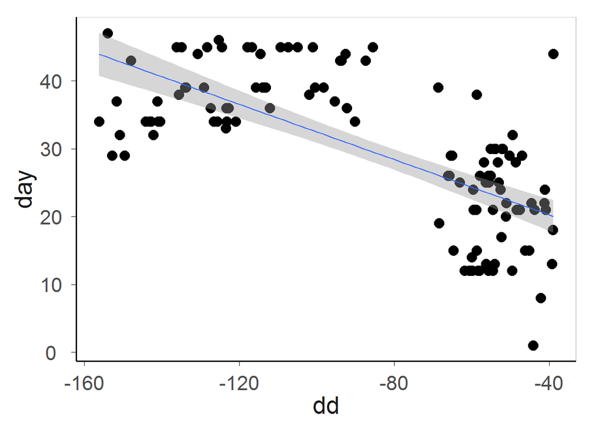

```r
  # First, plot the relationship between passage day and breeding latitude
  ggplot(data = amre_stop, aes(x = dd, y = day)) + geom_point() + stat_smooth(method = "lm")
```

```r
  # Fit linear regression model
  mod1 <- with(amre_stop, lm(day ~ dd))

  # View model results
  summary(mod1)
```

```
##
## Call:
## lm(formula = day ~ dd)
##
## Residuals:
##     Min      1Q  Median      3Q     Max
## -20.110  -6.561   0.519   5.595  23.964
##
## Coefficients:
##             Estimate Std. Error t value Pr(>|t|)
## (Intercept)  12.1181     1.8869    6.42  3.2e-09 ***
## dd           -0.2035     0.0202  -10.10  < 2e-16 ***
## ---
## Signif. codes:  0 '***' 0.001 '**' 0.01 '*' 0.05 '.' 0.1 ' ' 1
##
## Residual standard error: 8.08 on 114 degrees of freedom
## Multiple R-squared:  0.472,  Adjusted R-squared:  0.468
## F-statistic:  102 on 1 and 114 DF,  p-value: <2e-16
```

The steep slope of the regression line and the significant p-value indicates that breeding latitude has a significant impact on passage date. Technically, we shouldn’t use the p-value from lm to judge significance. It is better to fit a model without breeding latitude and compare the two models using a likelihood ratio test:

```r
  # Fit intercept-only model
  mod2 <- with(amre_stop, lm(day ~ 1))

  # Compare models using likelihood ratio test
  anova(mod2, mod1)
```

```
## Analysis of Variance Table
##
## Model 1: day ~ 1
## Model 2: day ~ dd
##   Res.Df   RSS Df Sum of Sq   F Pr(>F)
## 1    115 14094
## 2    114  7439  1      6655 102 <2e-16 ***
## ---
## Signif. codes:  0 '***' 0.001 '**' 0.01 '*' 0.05 '.' 0.1 ' ' 1
```

As expected, the result is highly signficant. But there is still a lot of unexplained variation in passage timing. Maybe some of that variation is driven by differences in passage timing across sites. Let’s test that:

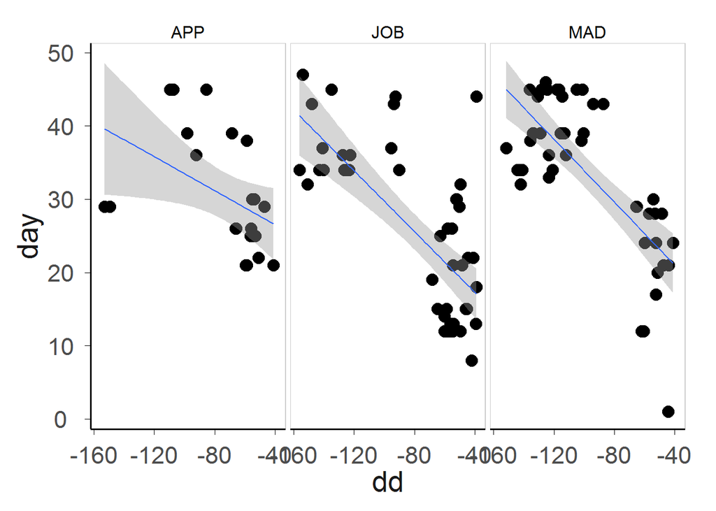

```r
  # Again, plot the relationship between passage day and site
  ggplot(data = amre_stop, aes(x = dd, y = day)) + geom_point() +
    stat_smooth(method = "lm") +
    facet_wrap(~site, nrow = 1)
```

```r
  # Fit intercept-only model
  mod3 <- with(amre_stop, lm(day ~ dd*site))
  summary(mod3)
```

```
##
## Call:
## lm(formula = day ~ dd * site)
##
## Residuals:
##     Min      1Q  Median      3Q     Max
## -20.913  -5.993  -0.522   5.059  26.957
##
## Coefficients:
##             Estimate Std. Error t value Pr(>|t|)
## (Intercept)  21.8994     4.3314    5.06  1.7e-06 ***
## dd           -0.1159     0.0537   -2.16    0.033 *
## siteJOB     -12.9281     5.0287   -2.57    0.011 *
## siteMAD      -9.4704     5.4915   -1.72    0.087 .
## dd:siteJOB   -0.0916     0.0610   -1.50    0.136
## dd:siteMAD   -0.0988     0.0627   -1.58    0.118
## ---
## Signif. codes:  0 '***' 0.001 '**' 0.01 '*' 0.05 '.' 0.1 ' ' 1
##
## Residual standard error: 7.73 on 110 degrees of freedom
## Multiple R-squared:  0.534,  Adjusted R-squared:  0.513
## F-statistic: 25.2 on 5 and 110 DF,  p-value: <2e-16
```

```r
  # Compare models using likelihood ratio test
  anova(mod3, mod1)
```

```
## Analysis of Variance Table
##
## Model 1: day ~ dd * site
## Model 2: day ~ dd
##   Res.Df  RSS Df Sum of Sq    F Pr(>F)
## 1    110 6565
## 2    114 7439 -4      -874 3.66 0.0077 **
## ---
## Signif. codes:  0 '***' 0.001 '**' 0.01 '*' 0.05 '.' 0.1 ' ' 1
```

There are many other interesting questions we could explore with these data but for the sake of time, we will leave that for personal fulfillment (or hopefully check back for the awesome paper that we will write using these very same data!).